# OT Summary

## CONSORT Flow Diagram

[interactive chart not shown]

## Overall status

| Characteristic | Overall1 | Control1 | Treatment1 |
| --- | --- | --- | --- |
| time_point |  |  |  |
| 1st | 155 | 77 | 78 |
| 2nd | 141 | 75 | 66 |

1n

## Demographic information

| Characteristic | N | Overall, N = 1551 | control, N = 771 | treatment, N = 781 | p-value2 |
| --- | --- | --- | --- | --- | --- |
| age | 155 | 47.75 ± 13.54 (20 - 77) | 49.10 ± 14.25 (20 - 74) | 46.42 ± 12.76 (22 - 77) | 0.218 |
| gender | 155 |  |  |  | 0.890 |
| female |  | 116 (75%) | 58 (75%) | 58 (74%) |  |
| male |  | 39 (25%) | 19 (25%) | 20 (26%) |  |
| occupation | 155 |  |  |  | 0.726 |
| civil |  | 3 (1.9%) | 2 (2.6%) | 1 (1.3%) |  |
| clerk |  | 16 (10%) | 6 (7.8%) | 10 (13%) |  |
| craft |  | 1 (0.6%) | 1 (1.3%) | 0 (0%) |  |
| homemaker |  | 14 (9.0%) | 7 (9.1%) | 7 (9.0%) |  |
| manager |  | 2 (1.3%) | 2 (2.6%) | 0 (0%) |  |
| other |  | 31 (20%) | 19 (25%) | 12 (15%) |  |
| professional |  | 3 (1.9%) | 1 (1.3%) | 2 (2.6%) |  |
| retired |  | 33 (21%) | 17 (22%) | 16 (21%) |  |
| service |  | 10 (6.5%) | 4 (5.2%) | 6 (7.7%) |  |
| student |  | 3 (1.9%) | 1 (1.3%) | 2 (2.6%) |  |
| unemploy |  | 39 (25%) | 17 (22%) | 22 (28%) |  |
| marital | 155 |  |  |  | 0.310 |
| divorced |  | 20 (13%) | 6 (7.8%) | 14 (18%) |  |
| married |  | 34 (22%) | 18 (23%) | 16 (21%) |  |
| other |  | 1 (0.6%) | 0 (0%) | 1 (1.3%) |  |
| single |  | 96 (62%) | 51 (66%) | 45 (58%) |  |
| widowed |  | 4 (2.6%) | 2 (2.6%) | 2 (2.6%) |  |
| education | 155 |  |  |  | 0.597 |
| post-secondary |  | 40 (26%) | 23 (30%) | 17 (22%) |  |
| primary |  | 3 (1.9%) | 2 (2.6%) | 1 (1.3%) |  |
| secondary |  | 68 (44%) | 32 (42%) | 36 (46%) |  |
| university |  | 44 (28%) | 20 (26%) | 24 (31%) |  |
| family_income | 155 |  |  |  | 0.532 |
| 0_10000 |  | 76 (49%) | 39 (51%) | 37 (47%) |  |
| 10001_20000 |  | 43 (28%) | 19 (25%) | 24 (31%) |  |
| 20001_30000 |  | 17 (11%) | 9 (12%) | 8 (10%) |  |
| 30001_40000 |  | 7 (4.5%) | 2 (2.6%) | 5 (6.4%) |  |
| 40000_above |  | 12 (7.7%) | 8 (10%) | 4 (5.1%) |  |
| religion | 155 |  |  |  | 0.856 |
| buddhism |  | 10 (6.5%) | 4 (5.2%) | 6 (7.7%) |  |
| catholic |  | 5 (3.2%) | 2 (2.6%) | 3 (3.8%) |  |
| christianity |  | 79 (51%) | 41 (53%) | 38 (49%) |  |
| nil |  | 60 (39%) | 29 (38%) | 31 (40%) |  |
| taoism |  | 1 (0.6%) | 1 (1.3%) | 0 (0%) |  |
| source | 155 |  |  |  | 0.620 |
| bokss |  | 85 (55%) | 44 (57%) | 41 (53%) |  |
| facebook |  | 26 (17%) | 12 (16%) | 14 (18%) |  |
| instagram |  | 2 (1.3%) | 2 (2.6%) | 0 (0%) |  |
| other |  | 18 (12%) | 7 (9.1%) | 11 (14%) |  |
| refresh |  | 24 (15%) | 12 (16%) | 12 (15%) |  |
| diagnosis_type | 155 |  |  |  | 0.842 |
| anxiety |  | 27 (17%) | 16 (21%) | 11 (14%) |  |
| bipolar |  | 16 (10%) | 7 (9.1%) | 9 (12%) |  |
| depression |  | 51 (33%) | 25 (32%) | 26 (33%) |  |
| other |  | 20 (13%) | 9 (12%) | 11 (14%) |  |
| psychosis |  | 41 (26%) | 20 (26%) | 21 (27%) |  |

1Mean ± SD (Range); n (%)  
2Two Sample t-test; Pearson's Chi-squared test; Fisher's exact test

## Measurement

| Characteristic | N | Overall, N = 1551 | control, N = 771 | treatment, N = 781 | p-value2 |
| --- | --- | --- | --- | --- | --- |
| fse | 155 | 17.68 ± 4.19 (9 - 30) | 17.69 ± 4.02 (10 - 30) | 17.67 ± 4.38 (9 - 28) | 0.974 |
| fa | 155 | 23.95 ± 3.55 (12 - 30) | 23.34 ± 3.73 (12 - 30) | 24.56 ± 3.28 (16 - 30) | 0.031 |
| fb | 155 | 18.31 ± 5.28 (6 - 30) | 17.95 ± 4.70 (8 - 30) | 18.67 ± 5.81 (6 - 29) | 0.399 |
| fwb | 155 | 45.26 ± 10.78 (14 - 86) | 45.30 ± 9.38 (14 - 69) | 45.22 ± 12.06 (14 - 86) | 0.963 |
| who | 155 | 9.83 ± 4.79 (0 - 25) | 9.48 ± 4.33 (0 - 24) | 10.18 ± 5.22 (0 - 25) | 0.366 |
| phq | 155 | 9.84 ± 6.44 (0 - 25) | 9.53 ± 6.53 (0 - 25) | 10.14 ± 6.38 (0 - 24) | 0.558 |
| gad | 155 | 8.37 ± 6.41 (0 - 21) | 8.45 ± 6.48 (0 - 21) | 8.29 ± 6.37 (0 - 21) | 0.877 |
| nb_pcs | 155 | 41.22 ± 9.73 (14 - 63) | 41.67 ± 9.75 (19 - 63) | 40.78 ± 9.76 (14 - 63) | 0.572 |
| nb_mcs | 155 | 40.83 ± 12.44 (12 - 68) | 40.73 ± 12.20 (12 - 68) | 40.93 ± 12.76 (13 - 67) | 0.924 |

1Mean ± SD (Range)  
2Two Sample t-test

## Data analysis

### Table

| Group | Characteristic | Beta | SE1 | 95% CI1 | p-value |
| --- | --- | --- | --- | --- | --- |
| fse | (Intercept) | 17.731 | 0.454 | 16.841, 18.622 |  |
|  | group |  |  |  |  |
|  | control | — | — | — |  |
|  | treatment | -0.107 | 0.638 | -1.357, 1.143 | 0.866 |
|  | time_point |  |  |  |  |
|  | 1st | — | — | — |  |
|  | 2nd | -0.235 | 0.409 | -1.037, 0.567 | 0.567 |
|  | group * time_point |  |  |  |  |
|  | treatment * 2nd | 2.027 | 0.595 | 0.861, 3.194 | 0.001 |
|  | Pseudo R square | 0.034 |  |  |  |
| fa | (Intercept) | 23.417 | 0.457 | 22.520, 24.313 |  |
|  | group |  |  |  |  |
|  | control | — | — | — |  |
|  | treatment | 1.069 | 0.645 | -0.194, 2.332 | 0.098 |
|  | time_point |  |  |  |  |
|  | 1st | — | — | — |  |
|  | 2nd | 0.225 | 0.576 | -0.904, 1.354 | 0.697 |
|  | group * time_point |  |  |  |  |
|  | treatment * 2nd | 0.352 | 0.831 | -1.276, 1.981 | 0.672 |
|  | Pseudo R square | 0.025 |  |  |  |
| fb | (Intercept) | 18.305 | 0.631 | 17.069, 19.541 |  |
|  | group |  |  |  |  |
|  | control | — | — | — |  |
|  | treatment | 0.009 | 0.884 | -1.725, 1.742 | 0.992 |
|  | time_point |  |  |  |  |
|  | 1st | — | — | — |  |
|  | 2nd | 0.856 | 0.544 | -0.211, 1.923 | 0.118 |
|  | group * time_point |  |  |  |  |
|  | treatment * 2nd | 1.048 | 0.792 | -0.504, 2.600 | 0.188 |
|  | Pseudo R square | 0.019 |  |  |  |

[output cut: 60 more lines]

1SE = Standard Error, CI = Confidence Interval

### Text

**fse**

We fitted a linear mixed model (estimated using REML and nloptwrap optimizer) to predict fse with group and time_point (formula: fse ~ 1 + group + time_point + group * time_point). The model included login_id as random effect (formula: ~1 | login_id). The model’s total explanatory power is substantial (conditional R2 = 0.62) and the part related to the fixed effects alone (marginal R2) is of 0.03. The model’s intercept, corresponding to group = control and time_point = 1st , is at 17.73 (S.E. = 0.45, p < .001, 95% CI [16.84, 18.62]). Within this model:

- The effect of group [treatment] is statistically non-significant and negative (beta = -0.11, S.E. = 0.64, p = 0.866, 95% CI [-1.36, 1.14]; Std. beta = -0.03, 95% CI [-0.33, 0.28])
- The effect of time point [2nd] is statistically non-significant and negative (beta = -0.23, S.E. = 0.41, p = 0.566, 95% CI [-1.04, 0.57]; Std. beta = -0.06, 95% CI [-0.26, 0.14])
- The interaction effect of time point [2nd] on group [treatment] is statistically significant and positive (beta = 2.03, S.E. = 0.59, p < .001, 95% CI [0.86, 3.19]; Std. beta = 0.50, 95% CI [0.21, 0.79])

Standardized parameters were obtained by fitting the model on a standardized version of the dataset. 95% Confidence Intervals (CIs) and p-values were computed using a Wald normal distribution approximation.

**fa**

We fitted a linear mixed model (estimated using REML and nloptwrap optimizer) to predict fa with group and time_point (formula: fa ~ 1 + group + time_point + group * time_point). The model included login_id as random effect (formula: ~1 | login_id). The model’s total explanatory power is moderate (conditional R2 = 0.24) and the part related to the fixed effects alone (marginal R2) is of 0.03. The model’s intercept, corresponding to group = control and time_point = 1st , is at 23.42 (S.E. = 0.46, p < .001, 95% CI [22.52, 24.31]). Within this model:

- The effect of group [treatment] is statistically non-significant and positive (beta = 1.07, S.E. = 0.64, p = 0.097, 95% CI [-0.19, 2.33]; Std. beta = 0.26, 95% CI [-0.05, 0.57])
- The effect of time point [2nd] is statistically non-significant and positive (beta = 0.22, S.E. = 0.58, p = 0.696, 95% CI [-0.90, 1.35]; Std. beta = 0.06, 95% CI [-0.22, 0.33])
- The interaction effect of time point [2nd] on group [treatment] is statistically non-significant and positive (beta = 0.35, S.E. = 0.83, p = 0.672, 95% CI [-1.28, 1.98]; Std. beta = 0.09, 95% CI [-0.31, 0.49])

Standardized parameters were obtained by fitting the model on a standardized version of the dataset. 95% Confidence Intervals (CIs) and p-values were computed using a Wald normal distribution approximation.

**fb**

We fitted a linear mixed model (estimated using REML and nloptwrap optimizer) to predict fb with group and time_point (formula: fb ~ 1 + group + time_point + group * time_point). The model included login_id as random effect (formula: ~1 | login_id). The model’s total explanatory power is substantial (conditional R2 = 0.65) and the part related to the fixed effects alone (marginal R2) is of 0.02. The model’s intercept, corresponding to group = control and time_point = 1st , is at 18.31 (S.E. = 0.63, p < .001, 95% CI [17.07, 19.54]). Within this model:

- The effect of group [treatment] is statistically non-significant and positive (beta = 8.76e-03, S.E. = 0.88, p = 0.992, 95% CI [-1.72, 1.74]; Std. beta = 1.56e-03, 95% CI [-0.31, 0.31])
- The effect of time point [2nd] is statistically non-significant and positive (beta = 0.86, S.E. = 0.54, p = 0.116, 95% CI [-0.21, 1.92]; Std. beta = 0.15, 95% CI [-0.04, 0.34])
- The interaction effect of time point [2nd] on group [treatment] is statistically non-significant and positive (beta = 1.05, S.E. = 0.79, p = 0.186, 95% CI [-0.50, 2.60]; Std. beta = 0.19, 95% CI [-0.09, 0.46])

Standardized parameters were obtained by fitting the model on a standardized version of the dataset. 95% Confidence Intervals (CIs) and p-values were computed using a Wald normal distribution approximation.

**fwb**

We fitted a linear mixed model (estimated using REML and nloptwrap optimizer) to predict fwb with group and time_point (formula: fwb ~ 1 + group + time_point + group * time_point). The model included login_id as random effect (formula: ~1 | login_id). The model’s total explanatory power is substantial (conditional R2 = 0.74) and the part related to the fixed effects alone (marginal R2) is of 0.02. The model’s intercept, corresponding to group = control and time_point = 1st , is at 45.38 (S.E. = 1.25, p < .001, 95% CI [42.94, 47.83]). Within this model:

- The effect of group [treatment] is statistically non-significant and negative (beta = -0.25, S.E. = 1.74, p = 0.886, 95% CI [-3.67, 3.17]; Std. beta = -0.02, 95% CI [-0.33, 0.29])
- The effect of time point [2nd] is statistically non-significant and positive (beta = 1.40, S.E. = 0.93, p = 0.130, 95% CI [-0.41, 3.21]; Std. beta = 0.13, 95% CI [-0.04, 0.29])
- The interaction effect of time point [2nd] on group [treatment] is statistically non-significant and positive (beta = 2.39, S.E. = 1.35, p = 0.076, 95% CI [-0.25, 5.04]; Std. beta = 0.22, 95% CI [-0.02, 0.46])

Standardized parameters were obtained by fitting the model on a standardized version of the dataset. 95% Confidence Intervals (CIs) and p-values were computed using a Wald normal distribution approximation.

**who**

We fitted a linear mixed model (estimated using REML and nloptwrap optimizer) to predict who with group and time_point (formula: who ~ 1 + group + time_point + group * time_point). The model included login_id as random effect (formula: ~1 | login_id). The model’s total explanatory power is substantial (conditional R2 = 0.70) and the part related to the fixed effects alone (marginal R2) is of 0.01. The model’s intercept, corresponding to group = control and time_point = 1st , is at 9.75 (S.E. = 0.55, p < .001, 95% CI [8.67, 10.82]). Within this model:

- The effect of group [treatment] is statistically non-significant and positive (beta = 0.17, S.E. = 0.77, p = 0.822, 95% CI [-1.33, 1.68]; Std. beta = 0.04, 95% CI [-0.27, 0.35])
- The effect of time point [2nd] is statistically non-significant and positive (beta = 0.30, S.E. = 0.43, p = 0.485, 95% CI [-0.55, 1.16]; Std. beta = 0.06, 95% CI [-0.11, 0.24])
- The interaction effect of time point [2nd] on group [treatment] is statistically non-significant and positive (beta = 0.89, S.E. = 0.63, p = 0.158, 95% CI [-0.35, 2.13]; Std. beta = 0.18, 95% CI [-0.07, 0.44])

Standardized parameters were obtained by fitting the model on a standardized version of the dataset. 95% Confidence Intervals (CIs) and p-values were computed using a Wald normal distribution approximation.

**phq**

We fitted a linear mixed model (estimated using REML and nloptwrap optimizer) to predict phq with group and time_point (formula: phq ~ 1 + group + time_point + group * time_point). The model included login_id as random effect (formula: ~1 | login_id). The model’s total explanatory power is substantial (conditional R2 = 0.77) and the part related to the fixed effects alone (marginal R2) is of 0.02. The model’s intercept, corresponding to group = control and time_point = 1st , is at 9.69 (S.E. = 0.72, p < .001, 95% CI [8.28, 11.09]). Within this model:

- The effect of group [treatment] is statistically non-significant and positive (beta = 0.30, S.E. = 1.00, p = 0.760, 95% CI [-1.65, 2.26]; Std. beta = 0.05, 95% CI [-0.26, 0.35])
- The effect of time point [2nd] is statistically significant and negative (beta = -1.41, S.E. = 0.50, p = 0.005, 95% CI [-2.39, -0.44]; Std. beta = -0.22, 95% CI [-0.38, -0.07])
- The interaction effect of time point [2nd] on group [treatment] is statistically non-significant and negative (beta = -0.88, S.E. = 0.73, p = 0.229, 95% CI [-2.30, 0.55]; Std. beta = -0.14, 95% CI [-0.36, 0.09])

Standardized parameters were obtained by fitting the model on a standardized version of the dataset. 95% Confidence Intervals (CIs) and p-values were computed using a Wald normal distribution approximation.

**gad**

We fitted a linear mixed model (estimated using REML and nloptwrap optimizer) to predict gad with group and time_point (formula: gad ~ 1 + group + time_point + group * time_point). The model included login_id as random effect (formula: ~1 | login_id). The model’s total explanatory power is substantial (conditional R2 = 0.81) and the part related to the fixed effects alone (marginal R2) is of 0.02. The model’s intercept, corresponding to group = control and time_point = 1st , is at 8.63 (S.E. = 0.71, p < .001, 95% CI [7.23, 10.03]). Within this model:

- The effect of group [treatment] is statistically non-significant and negative (beta = -0.50, S.E. = 0.99, p = 0.612, 95% CI [-2.45, 1.44]; Std. beta = -0.08, 95% CI [-0.39, 0.23])
- The effect of time point [2nd] is statistically non-significant and negative (beta = -0.38, S.E. = 0.46, p = 0.403, 95% CI [-1.28, 0.51]; Std. beta = -0.06, 95% CI [-0.20, 0.08])
- The interaction effect of time point [2nd] on group [treatment] is statistically significant and negative (beta = -1.40, S.E. = 0.67, p = 0.036, 95% CI [-2.70, -0.09]; Std. beta = -0.22, 95% CI [-0.43, -0.01])

Standardized parameters were obtained by fitting the model on a standardized version of the dataset. 95% Confidence Intervals (CIs) and p-values were computed using a Wald normal distribution approximation.

**nb_pcs**

We fitted a linear mixed model (estimated using REML and nloptwrap optimizer) to predict nb_pcs with group and time_point (formula: nb_pcs ~ 1 + group + time_point + group * time_point). The model included login_id as random effect (formula: ~1 | login_id). The model’s total explanatory power is substantial (conditional R2 = 0.71) and the part related to the fixed effects alone (marginal R2) is of 7.61e-03. The model’s intercept, corresponding to group = control and time_point = 1st , is at 41.73 (S.E. = 1.10, p < .001, 95% CI [39.57, 43.90]). Within this model:

- The effect of group [treatment] is statistically non-significant and negative (beta = -1.02, S.E. = 1.54, p = 0.511, 95% CI [-4.04, 2.01]; Std. beta = -0.10, 95% CI [-0.41, 0.21])
- The effect of time point [2nd] is statistically non-significant and positive (beta = 0.63, S.E. = 0.85, p = 0.457, 95% CI [-1.04, 2.31]; Std. beta = 0.07, 95% CI [-0.11, 0.24])
- The interaction effect of time point [2nd] on group [treatment] is statistically non-significant and positive (beta = 1.70, S.E. = 1.24, p = 0.170, 95% CI [-0.73, 4.14]; Std. beta = 0.17, 95% CI [-0.07, 0.42])

Standardized parameters were obtained by fitting the model on a standardized version of the dataset. 95% Confidence Intervals (CIs) and p-values were computed using a Wald normal distribution approximation.

**nb_mcs**

We fitted a linear mixed model (estimated using REML and nloptwrap optimizer) to predict nb_mcs with group and time_point (formula: nb_mcs ~ 1 + group + time_point + group * time_point). The model included login_id as random effect (formula: ~1 | login_id). The model’s total explanatory power is substantial (conditional R2 = 0.77) and the part related to the fixed effects alone (marginal R2) is of 2.89e-03. The model’s intercept, corresponding to group = control and time_point = 1st , is at 40.63 (S.E. = 1.37, p < .001, 95% CI [37.95, 43.30]). Within this model:

- The effect of group [treatment] is statistically non-significant and positive (beta = 0.41, S.E. = 1.90, p = 0.831, 95% CI [-3.32, 4.14]; Std. beta = 0.03, 95% CI [-0.28, 0.34])
- The effect of time point [2nd] is statistically non-significant and positive (beta = 0.83, S.E. = 0.95, p = 0.382, 95% CI [-1.03, 2.68]; Std. beta = 0.07, 95% CI [-0.09, 0.22])
- The interaction effect of time point [2nd] on group [treatment] is statistically non-significant and positive (beta = 0.57, S.E. = 1.38, p = 0.681, 95% CI [-2.14, 3.27]; Std. beta = 0.05, 95% CI [-0.18, 0.27])

Standardized parameters were obtained by fitting the model on a standardized version of the dataset. 95% Confidence Intervals (CIs) and p-values were computed using a Wald normal distribution approximation.

## Likelihood ratio tests

| outcome | model | npar | AIC | BIC | logLik | deviance | Chisq | Df | p |
| --- | --- | --- | --- | --- | --- | --- | --- | --- | --- |
| fse | null | 3 | 1,617.352 | 1,628.424 | -805.676 | 1,611.352 |  |  |  |
| fse | random | 6 | 1,604.497 | 1,626.639 | -796.249 | 1,592.497 | 18.855 | 3 | 0.000 |
| fa | null | 3 | 1,664.364 | 1,675.435 | -829.182 | 1,658.364 |  |  |  |
| fa | random | 6 | 1,663.822 | 1,685.964 | -825.911 | 1,651.822 | 6.542 | 3 | 0.088 |
| fb | null | 3 | 1,797.015 | 1,808.086 | -895.507 | 1,791.015 |  |  |  |
| fb | random | 6 | 1,789.583 | 1,811.725 | -888.791 | 1,777.583 | 13.432 | 3 | 0.004 |
| fwb | null | 3 | 2,170.610 | 2,181.681 | -1,082.305 | 2,164.610 |  |  |  |
| fwb | random | 6 | 2,159.757 | 2,181.899 | -1,073.878 | 2,147.757 | 16.853 | 3 | 0.001 |
| who | null | 3 | 1,690.808 | 1,701.879 | -842.404 | 1,684.808 |  |  |  |
| who | random | 6 | 1,688.960 | 1,711.102 | -838.480 | 1,676.960 | 7.848 | 3 | 0.049 |
| phq | null | 3 | 1,835.038 | 1,846.109 | -914.519 | 1,829.038 |  |  |  |
| phq | random | 6 | 1,816.371 | 1,838.513 | -902.185 | 1,804.371 | 24.667 | 3 | 0.000 |
| gad | null | 3 | 1,803.955 | 1,815.026 | -898.978 | 1,797.955 |  |  |  |
| gad | random | 6 | 1,794.895 | 1,817.038 | -891.448 | 1,782.895 | 15.060 | 3 | 0.002 |
| nb_pcs | null | 3 | 2,097.782 | 2,108.853 | -1,045.891 | 2,091.782 |  |  |  |
| nb_pcs | random | 6 | 2,096.603 | 2,118.745 | -1,042.301 | 2,084.603 | 7.179 | 3 | 0.066 |
| nb_mcs | null | 3 | 2,194.328 | 2,205.399 | -1,094.164 | 2,188.328 |  |  |  |
| nb_mcs | random | 6 | 2,197.498 | 2,219.640 | -1,092.749 | 2,185.498 | 2.831 | 3 | 0.419 |

## Post hoc analysis text

### Table

| outcome | time | control n | control estimate | control within es | treatment n | treatment estimate | treatment within es | between p | between es |
| --- | --- | --- | --- | --- | --- | --- | --- | --- | --- |
| fse | 1st | 77 | 17.73 ± 3.99 |  | 78 | 17.62 ± 3.99 |  | 0.867 | 0.043 |
| fse | 2nd | 75 | 17.50 ± 3.97 | 0.093 | 66 | 19.42 ± 3.86 | -0.714 | 0.004 | -0.764 |
| fa | 1st | 77 | 23.42 ± 4.01 |  | 78 | 24.49 ± 4.01 |  | 0.098 | -0.302 |
| fa | 2nd | 75 | 23.64 ± 4.01 | -0.063 | 66 | 25.06 ± 4.00 | -0.163 | 0.036 | -0.401 |
| fb | 1st | 77 | 18.31 ± 5.54 |  | 78 | 18.31 ± 5.54 |  | 0.992 | -0.003 |
| fb | 2nd | 75 | 19.16 ± 5.51 | -0.256 | 66 | 20.22 ± 5.34 | -0.570 | 0.245 | -0.316 |
| fwb | 1st | 77 | 45.38 ± 10.95 |  | 78 | 45.13 ± 10.96 |  | 0.887 | 0.044 |
| fwb | 2nd | 75 | 46.78 ± 10.88 | -0.247 | 66 | 48.93 ± 10.44 | -0.669 | 0.228 | -0.378 |
| who | 1st | 77 | 9.75 ± 4.82 |  | 78 | 9.92 ± 4.82 |  | 0.823 | -0.065 |
| who | 2nd | 75 | 10.05 ± 4.79 | -0.114 | 66 | 11.11 ± 4.62 | -0.449 | 0.176 | -0.400 |
| phq | 1st | 77 | 9.69 ± 6.28 |  | 78 | 9.99 ± 6.28 |  | 0.760 | -0.100 |
| phq | 2nd | 75 | 8.27 ± 6.23 | 0.462 | 66 | 7.70 ± 5.96 | 0.748 | 0.574 | 0.186 |
| gad | 1st | 77 | 8.63 ± 6.28 |  | 78 | 8.12 ± 6.28 |  | 0.614 | 0.180 |
| gad | 2nd | 75 | 8.25 ± 6.22 | 0.136 | 66 | 6.34 ± 5.92 | 0.636 | 0.060 | 0.680 |
| nb_pcs | 1st | 77 | 41.73 ± 9.69 |  | 78 | 40.72 ± 9.69 |  | 0.512 | 0.194 |
| nb_pcs | 2nd | 75 | 42.37 ± 9.63 | -0.121 | 66 | 43.05 ± 9.26 | -0.447 | 0.662 | -0.132 |
| nb_mcs | 1st | 77 | 40.63 ± 11.99 |  | 78 | 41.03 ± 11.99 |  | 0.831 | -0.070 |
| nb_mcs | 2nd | 75 | 41.45 ± 11.90 | -0.143 | 66 | 42.43 ± 11.37 | -0.240 | 0.615 | -0.168 |

### Between group

**fse**

*1st*

t(228.49) = -0.17, p = 0.867, Cohen d = 0.04, 95% CI (-1.36 to 1.15)

*2st*

t(245.07) = 2.93, p = 0.004, Cohen d = -0.76, 95% CI (0.63 to 3.21)

**fa**

*1st*

t(280.43) = 1.66, p = 0.098, Cohen d = -0.30, 95% CI (-0.20 to 2.34)

*2st*

t(285.83) = 2.11, p = 0.036, Cohen d = -0.40, 95% CI (0.09 to 2.75)

**fb**

*1st*

t(224.14) = 0.01, p = 0.992, Cohen d = -0.00, 95% CI (-1.74 to 1.75)

*2st*

t(240.62) = 1.17, p = 0.245, Cohen d = -0.32, 95% CI (-0.73 to 2.84)

**fwb**

*1st*

t(213.25) = -0.14, p = 0.887, Cohen d = 0.04, 95% CI (-3.69 to 3.19)

*2st*

t(228.13) = 1.21, p = 0.228, Cohen d = -0.38, 95% CI (-1.35 to 5.64)

**who**

*1st*

t(217.01) = 0.22, p = 0.823, Cohen d = -0.06, 95% CI (-1.34 to 1.69)

*2st*

t(232.76) = 1.36, p = 0.176, Cohen d = -0.40, 95% CI (-0.48 to 2.61)

**phq**

*1st*

t(210.79) = 0.31, p = 0.760, Cohen d = -0.10, 95% CI (-1.66 to 2.27)

*2st*

t(224.71) = -0.56, p = 0.574, Cohen d = 0.19, 95% CI (-2.57 to 1.43)

**gad**

*1st*

t(208.98) = -0.51, p = 0.614, Cohen d = 0.18, 95% CI (-2.46 to 1.46)

*2st*

t(221.43) = -1.89, p = 0.060, Cohen d = 0.68, 95% CI (-3.88 to 0.08)

**nb_pcs**

*1st*

t(215.49) = -0.66, p = 0.512, Cohen d = 0.19, 95% CI (-4.06 to 2.03)

*2st*

t(230.94) = 0.44, p = 0.662, Cohen d = -0.13, 95% CI (-2.41 to 3.79)

**nb_mcs**

*1st*

t(210.58) = 0.21, p = 0.831, Cohen d = -0.07, 95% CI (-3.35 to 4.16)

*2st*

t(224.40) = 0.50, p = 0.615, Cohen d = -0.17, 95% CI (-2.83 to 4.78)

### Within treatment group

**fse**

*1st vs 2st*

t(147.54) = 4.15, p = 0.000, Cohen d = -0.71, 95% CI (0.94 to 2.65)

**fa**

*1st vs 2st*

t(154.43) = 0.96, p = 0.337, Cohen d = -0.16, 95% CI (-0.61 to 1.76)

**fb**

*1st vs 2st*

t(146.88) = 3.31, p = 0.001, Cohen d = -0.57, 95% CI (0.77 to 3.04)

**fwb**

*1st vs 2st*

t(144.86) = 3.87, p = 0.000, Cohen d = -0.67, 95% CI (1.85 to 5.74)

**who**

*1st vs 2st*

t(145.66) = 2.60, p = 0.010, Cohen d = -0.45, 95% CI (0.29 to 2.11)

**phq**

*1st vs 2st*

t(144.19) = -4.32, p = 0.000, Cohen d = 0.75, 95% CI (-3.34 to -1.24)

**gad**

*1st vs 2st*

t(143.34) = -3.67, p = 0.000, Cohen d = 0.64, 95% CI (-2.74 to -0.82)

**nb_pcs**

*1st vs 2st*

t(145.35) = 2.59, p = 0.011, Cohen d = -0.45, 95% CI (0.55 to 4.13)

**nb_mcs**

*1st vs 2st*

t(144.12) = 1.39, p = 0.168, Cohen d = -0.24, 95% CI (-0.59 to 3.38)

### Within control group

**fse**

*1st vs 2st*

t(140.66) = -0.57, p = 0.567, Cohen d = 0.09, 95% CI (-1.04 to 0.57)

**fa**

*1st vs 2st*

t(143.06) = 0.39, p = 0.697, Cohen d = -0.06, 95% CI (-0.91 to 1.36)

**fb**

*1st vs 2st*

t(140.49) = 1.57, p = 0.118, Cohen d = -0.26, 95% CI (-0.22 to 1.93)

**fwb**

*1st vs 2st*

t(139.98) = 1.51, p = 0.132, Cohen d = -0.25, 95% CI (-0.43 to 3.23)

**who**

*1st vs 2st*

t(140.18) = 0.70, p = 0.486, Cohen d = -0.11, 95% CI (-0.56 to 1.16)

**phq**

*1st vs 2st*

t(139.82) = -2.84, p = 0.005, Cohen d = 0.46, 95% CI (-2.40 to -0.43)

**gad**

*1st vs 2st*

t(139.63) = -0.84, p = 0.404, Cohen d = 0.14, 95% CI (-1.28 to 0.52)

**nb_pcs**

*1st vs 2st*

t(140.10) = 0.74, p = 0.459, Cohen d = -0.12, 95% CI (-1.05 to 2.32)

**nb_mcs**

*1st vs 2st*

t(139.81) = 0.87, p = 0.384, Cohen d = -0.14, 95% CI (-1.04 to 2.70)

### Plot

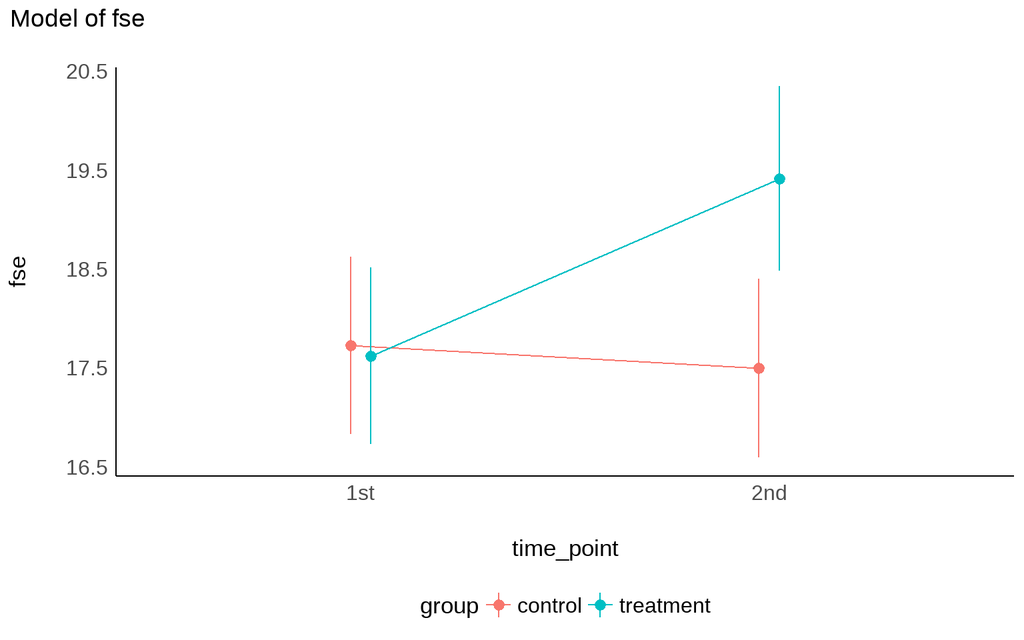

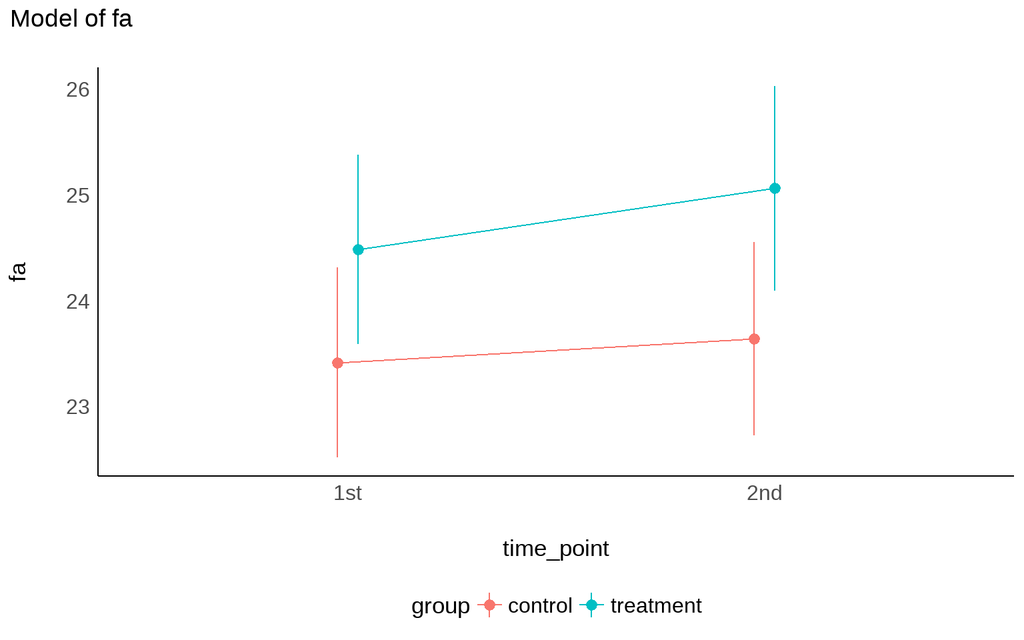

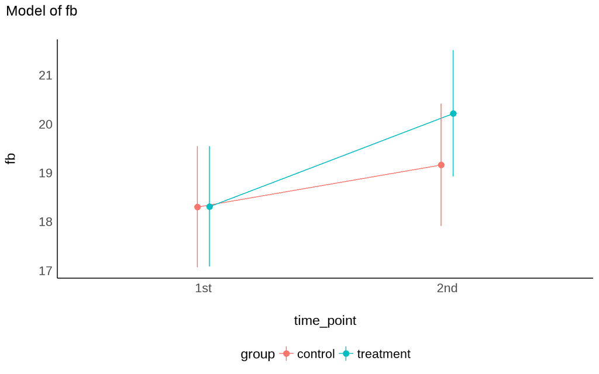

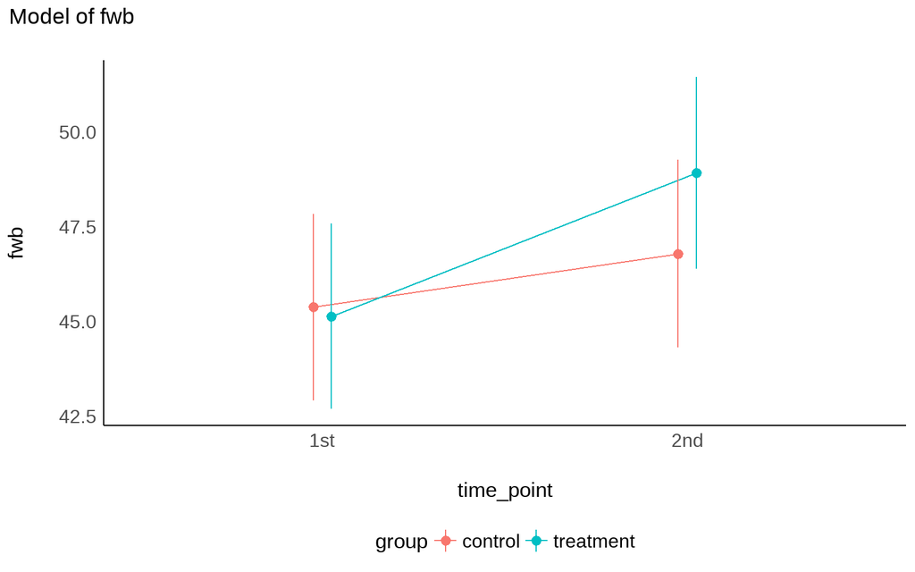

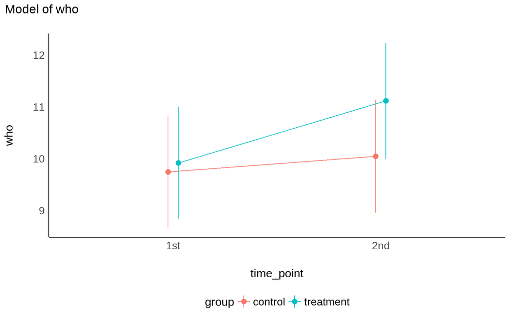

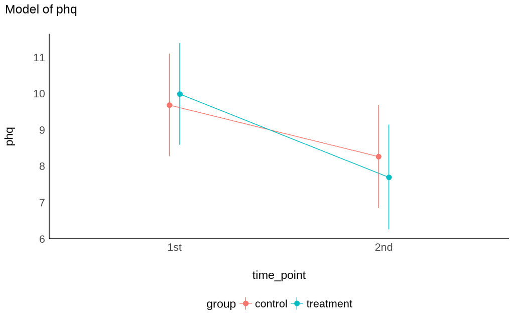

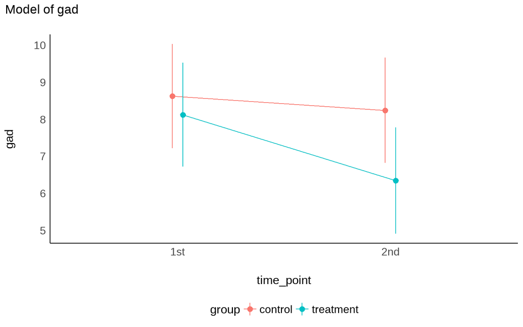

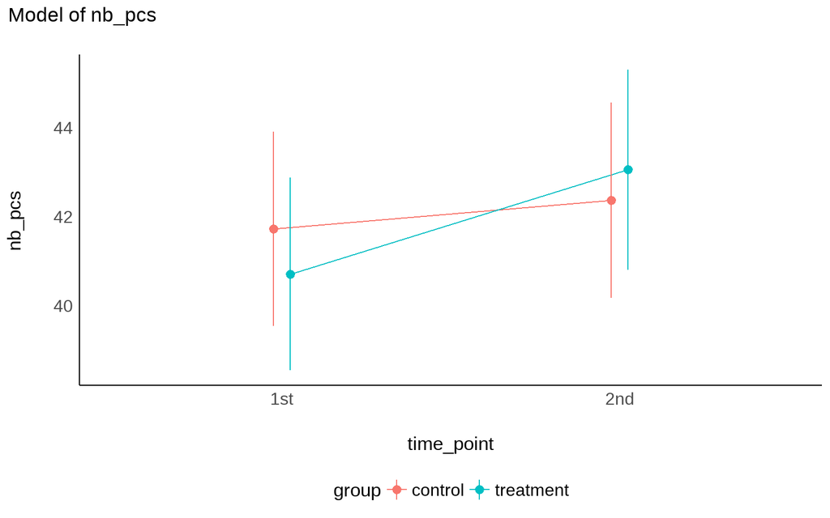

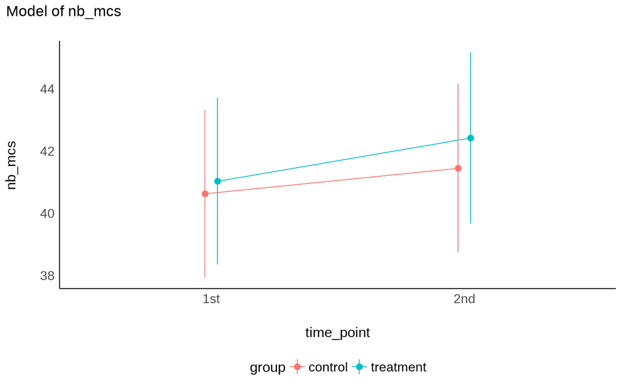